## Characterizing the between-host transmission of SARS-CoV-2 minor-variants in a linked cluster of infections

### Project Overview

The influence of genetic diversity accumulated within an infected individual on the global evolutionary dynamics of SARS-CoV-2 is unknown. Characterizing this dynamic requires an estimate of the amount of genetic variation transferred between individuals during an infection. Here, we leverage a unique dataset to measure this bottleneck. Deep-sequencing of RNA collected from a linked cluster of infections on an isolated fishing vessel enables the observation of the transmission of minor variants between individuals. We propose using this data to provide the highest resolution estimate of the inter-host transmission bottleneck for SARS-CoV-2 to date.

### Methods

#### Sequencing Data

From the 104 reportedly infected crew members, there are 39 metagenomic RNA-sequencing runs available. Libraries were sequenced on a 1x75 bp Illumina NextSeq run. A median of 509,551 sequencing reads were obtained for each sample. The data is publicly available at NCBI BioProject [`PRJNA610428`](https://www.ncbi.nlm.nih.gov/Traces/study/?query_key=2&WebEnv=MCID_5f344f743a76fab9ab22e42b&o=acc_s%3Aa).

#### Variant Calling

To measure intra-host variation in each sample, the data was processed through a variant calling pipeline. The raw sequencing reads were processed using `Fastp` to trim adaptor sequences, low-quality bases, filter low-quality reads, and trim poly-A tails. Processed reads were subsequently aligned to a reference (NC_045512) using either `BWA` or `STAR`, and variants were called using either `Varscan2` or `Lofreq`.

### Analysis

#### Included Samples

The paper has a supplementary table (Supplementary Table 2.) that includes the strain names for each individual and the GISAID ID for the consensus, but not the SRA accession. I used this information to search the Bioproject ([`PRJNA610428`](https://www.ncbi.nlm.nih.gov/Traces/study/?query_key=2&WebEnv=MCID_5f344f743a76fab9ab22e42b&o=acc_s%3Aa)) for the relevant samples. This Bioproject contains all of the samples sequenced by the UW Virology Department (~1000 Runs). Of the 39 samples referenced in the paper, there are 28 that had corresponding Runs deposited in this project and 11 that did not. As a quasi-control, I randomly sampled an equal number of sequencing runs from the rest of the UW bioproject that were done on the same sequencer, were also single-ended, and were within one standard deviation of the mean library size for the transmission cluster Runs.

#### Quality Contol

Data for the quality control portion of the analysis was collated by the tool `multiqc`. It consists of statistics produced by `samtools`, `STAR`, `fastp`, and `fastQC.` I’ve also included the coverage over each sample in this part of the analyis.

**The percentage of reads that mapped to SARS-CoV-2.**

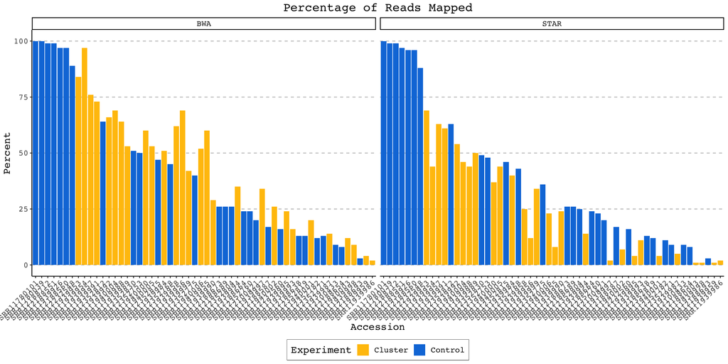

There is a tremendous amount of variation in the proportion of reads that correctly map. It’s fairly well distributed between the control and cluster samples, but on average the cluster samples have a lower mapping rate. Interestingly, there is a bigger effect of aligner choice (`STAR` v. `BWA`) on mapping rate in the cluster than the control. I wonder if this speaks to some underlying issues with sample quality that isn’t well summarized by mapping rate?

**The ratio of transitions to transversions in each sample.**

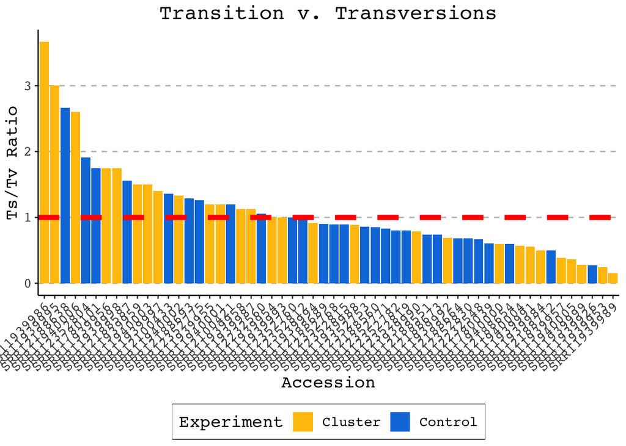

In theory, transitions are much more common than transversions biologically, however Illumina sequencing errors tend to bais towards transversions. Above, I plotted the ratio transitions (Ts) to transversions (Tv) for each sample and colored them by the experiment (cluster v. control). The cluster samples seem to have a higher ratio of transitions. I’m not sure what to make of this yet. This is just for BWA and Lofreq. From here on, I’ll just use that aligner-caller combo.

**The concordance between the pipeline for annotated SNPs.**

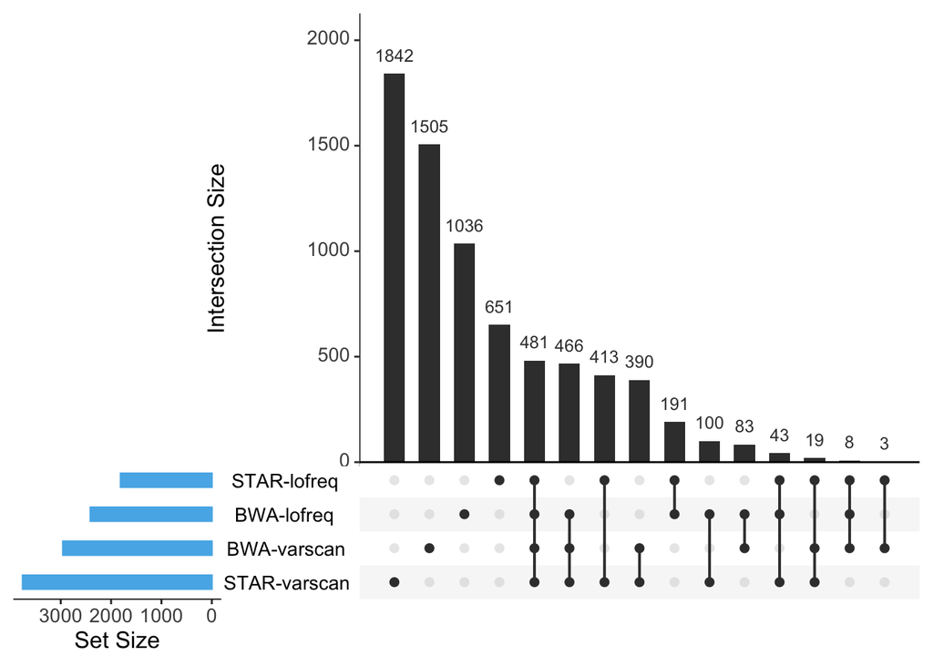

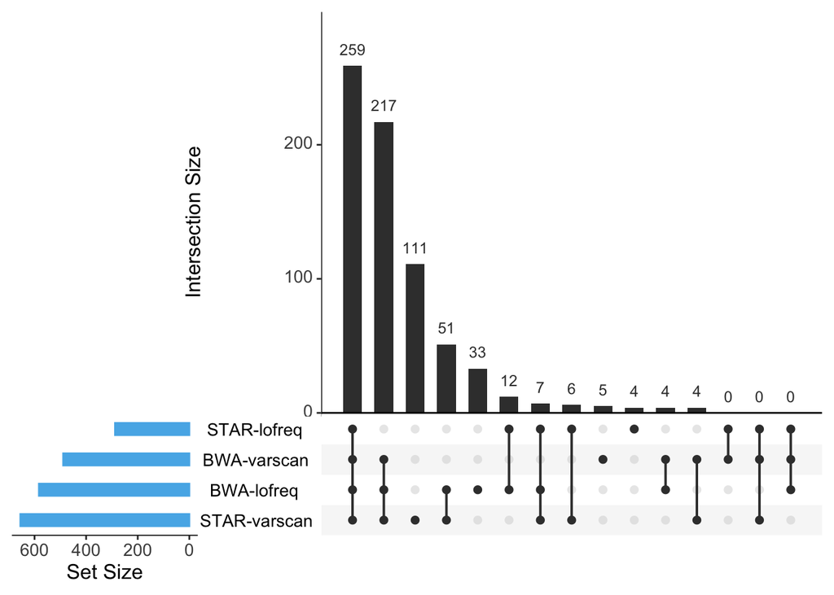

The difference in concordance between all variants (first plot) and just variants that have an allele frequency above 2% (second plot) is huge. It’s worth taking this into consideration in down stream analyses and perhaps filtering out alleles with frequencies less than 2%.

#### Mutational Spectra

**The ratio of Synonymous/Non-Synonymous/Missense mutations - all variants and only minor variants.**

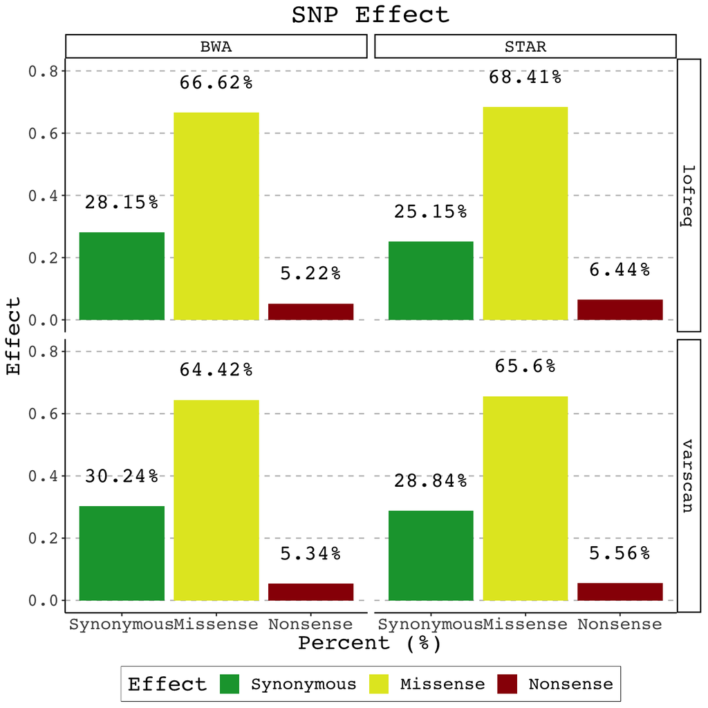

The ratio of mutational effects is very similar between the four combinations and consistent with other studies that I’ve seen.

**The distribution of nucleotide changes - all variants and only minor variants.**

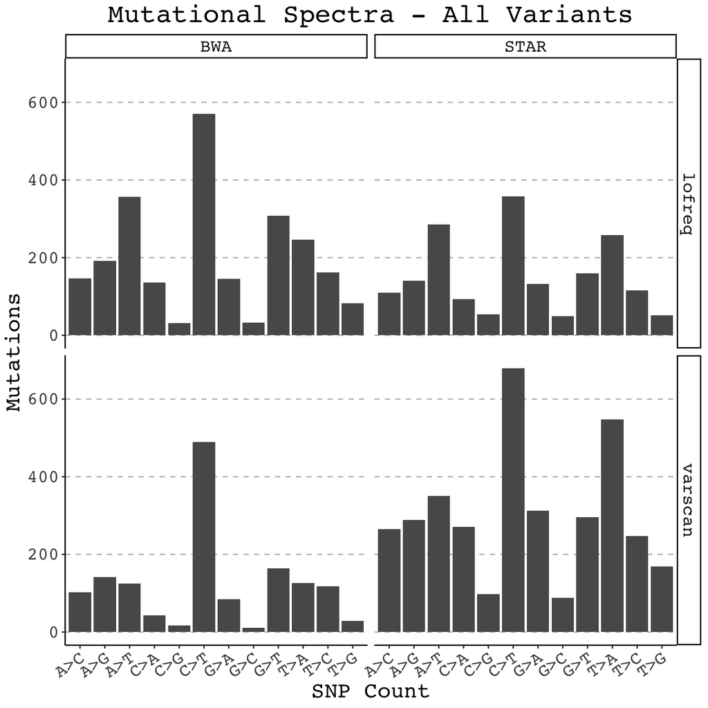

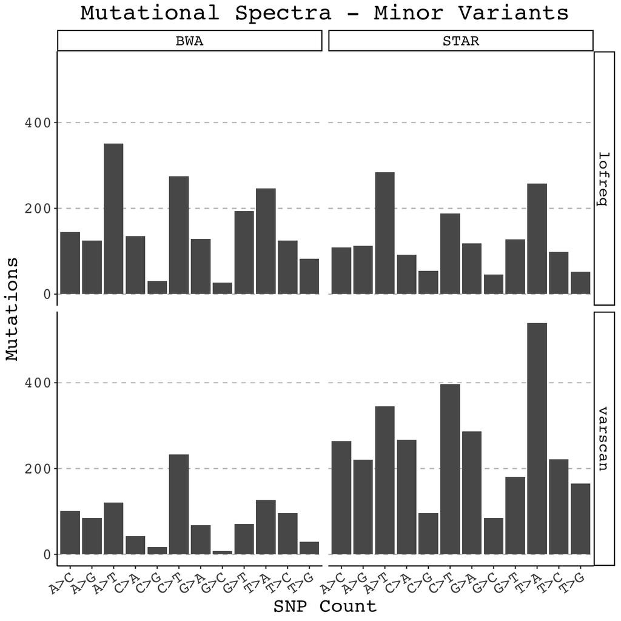

Similar to the Ts/Tv plot above, I wanted to see the mutational spectra for minor and major variants. Overall, there seems to be a slight bias towards C>T transtions, which is also consistent with other studies, but it’s not as apparent in only the minor variants.

**The distribution of nucleotide changes across genes, normalized to size - all variants and only minor variants.**

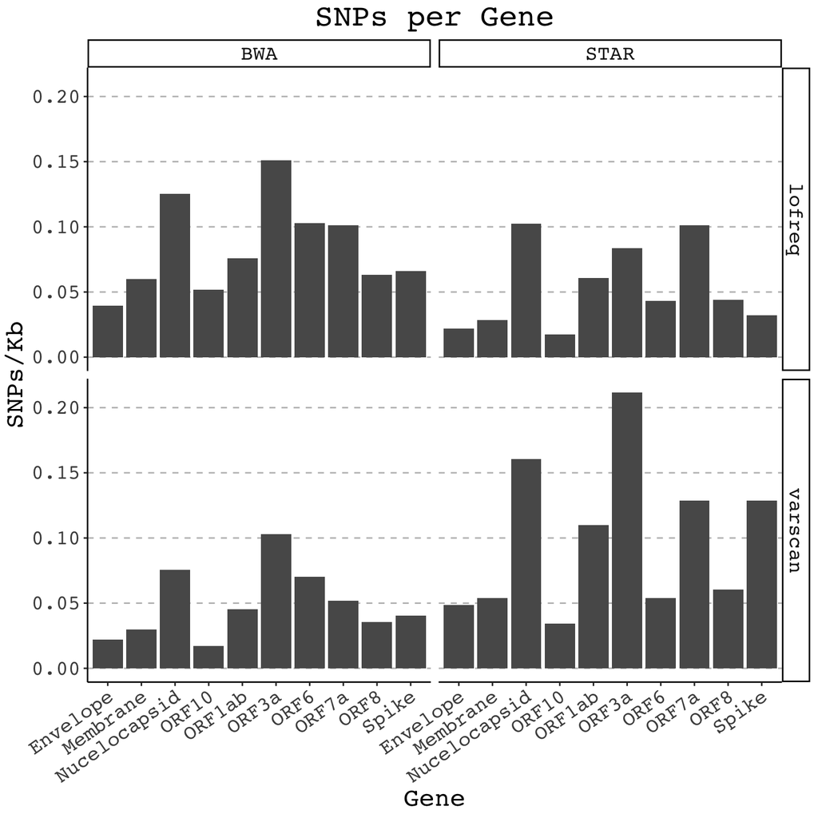

#### Shared Variation

**Dirstribution of minor variants.**

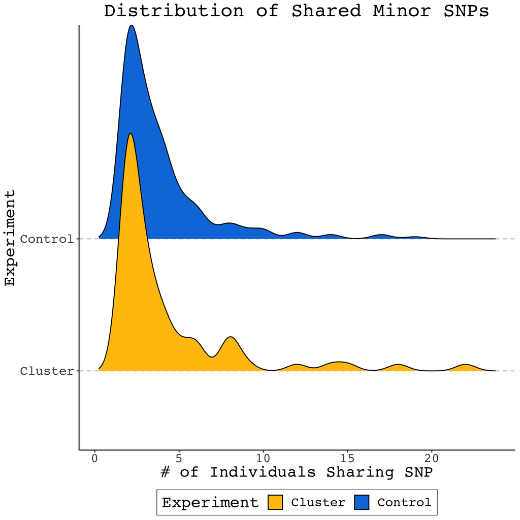

**Upset plot of shared Minor SNPs.**

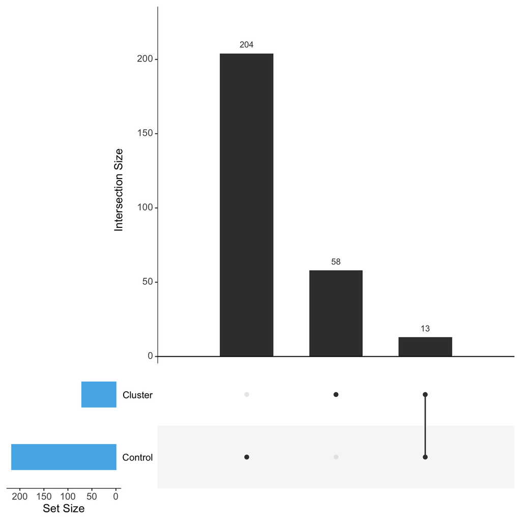

** Correlation between frequency of overlap and allele frequency in minor SNPs. **

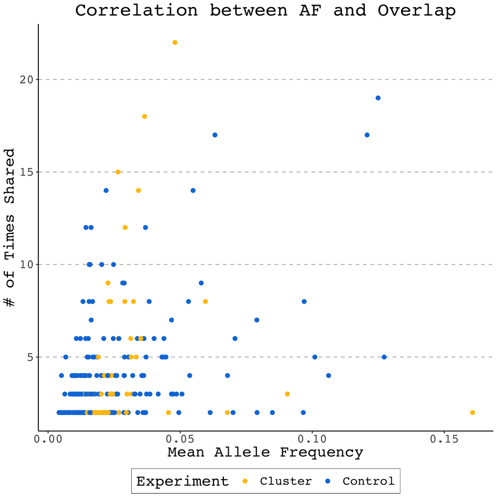

```
##      [,1] [,2]
## [1,]   71  217
## [2,]  127  593
```

```
##
##  Fisher's Exact Test for Count Data
##
## data:
## p-value = 0.01387
## alternative hypothesis: true odds ratio is not equal to 1
## 95 percent confidence interval:
##  1.080774 2.147583
## sample estimates:
## odds ratio
##   1.527071
```

[output not shown]

[output not shown]

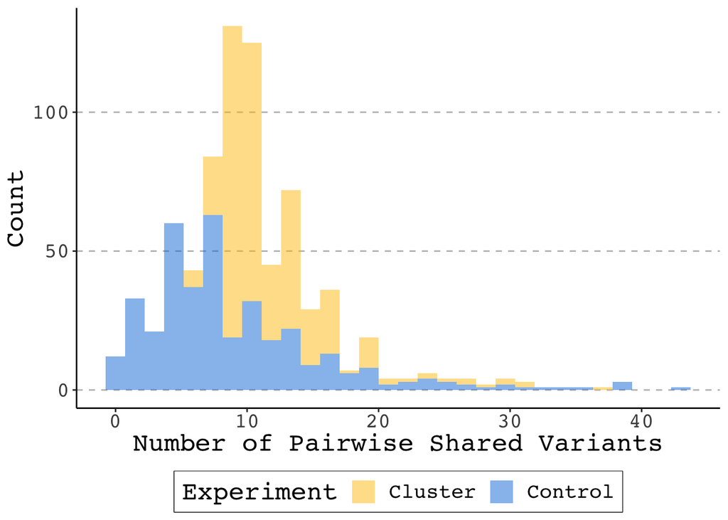